# MAB Simulations

Sandeep Gangarapu

# Simulation set up

Every time we pull an arm (make an allocation), we sample from the normal distribution of given by the mean and variance of that arm.

```r
true_means = c(0.25, 1.82, 1.48, 2.25, 2)

true_vars = c(2.84,  1.97, 2.62, 1, 2.06)

grp = c(0:(length(true_means)-1))
true_df <- data.frame(grp, true_means, true_vars)
true_df <- true_df %>% mutate(grp=factor(grp))
```

Time Horizon is the number of allocations we have available synonymous to number of experimental units in an experiment. In this simulation, we set time horizon to 2000 units.

We run this simulation for 20 different times using various seeds.

# Small sample properties of algortihms

## Best arm bias

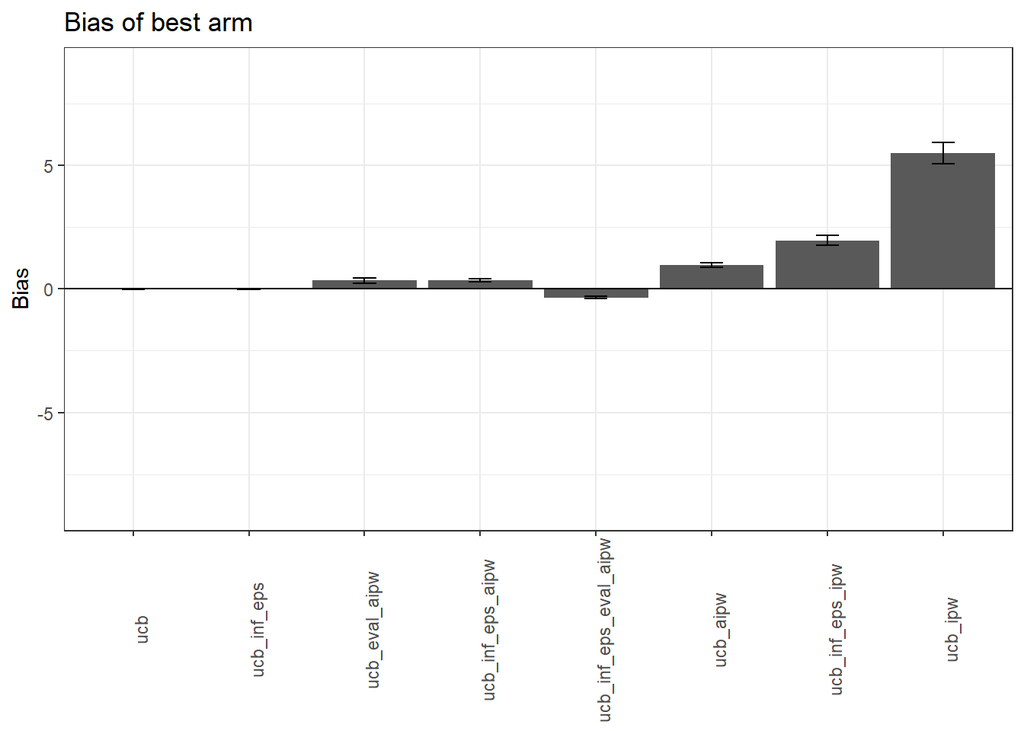

Weighed estimators have the highest bias, even for the best arm. This might be because of their high variance properties. As we only have 20 iterations, the bias might not be still converging to 0.

## Worst arm bias

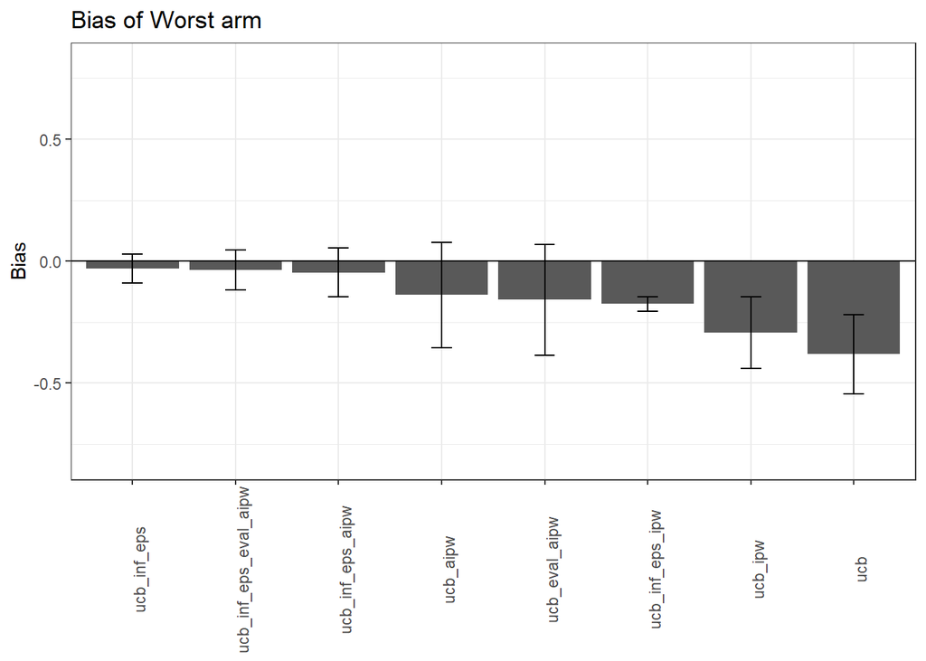

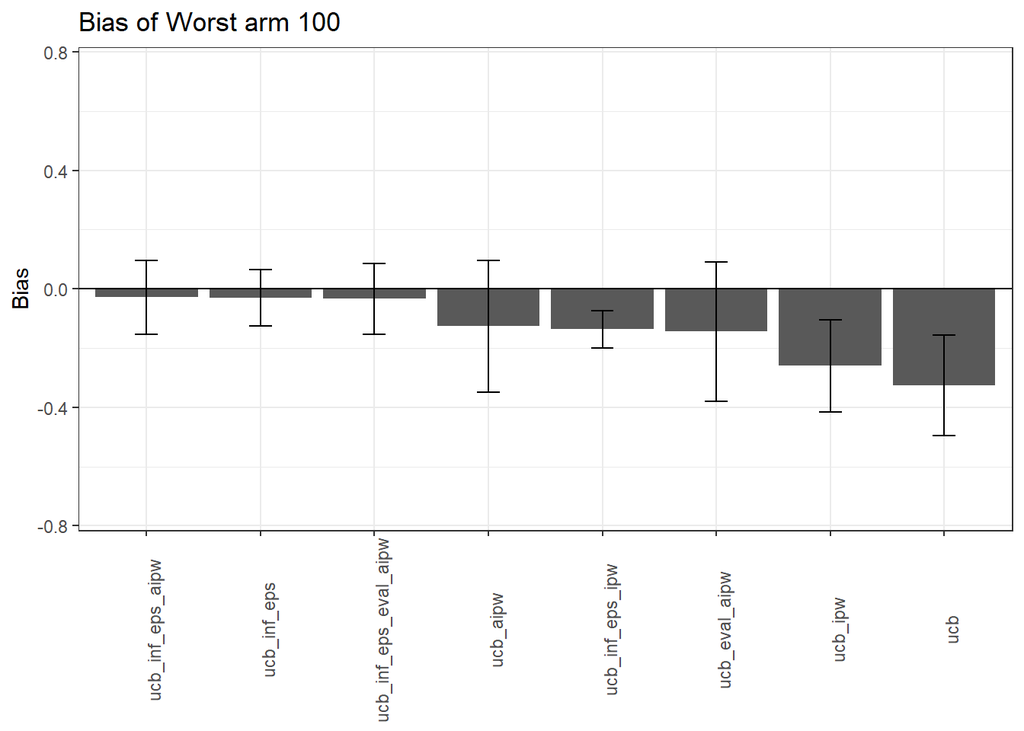

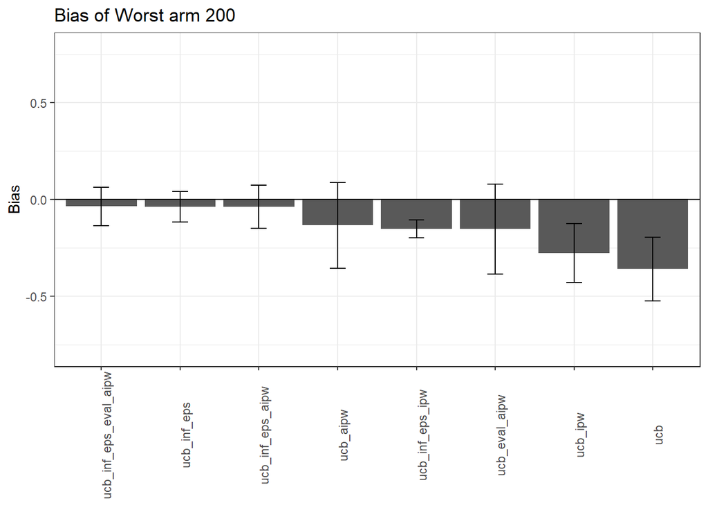

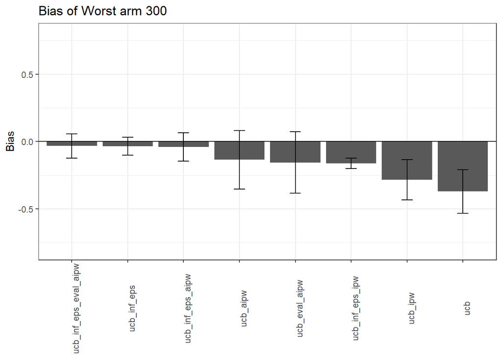

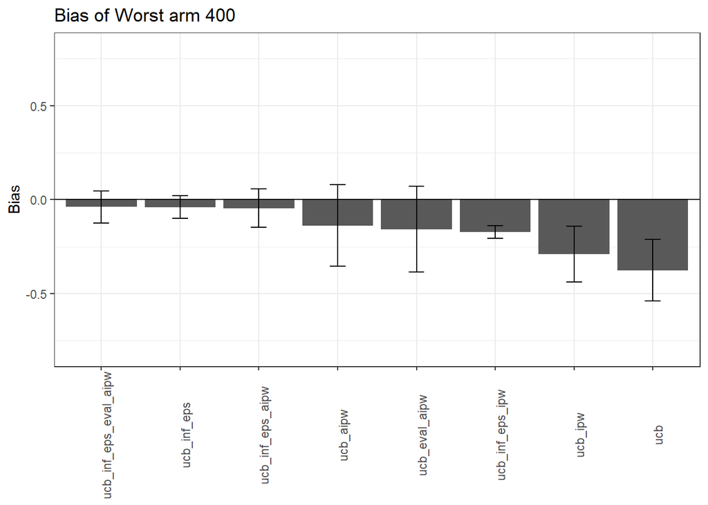

The relative value of bias is high for the worst arm.

*One thing to note is that, for thompson sampling based algorithms, we have to choose priors and update posteriors based on rewards, This is problem for worst arm. If we choose bad priors and they barely get allocations, then Bias and MSE will be high, even after using weighed estimators*

## MSE of Best arm

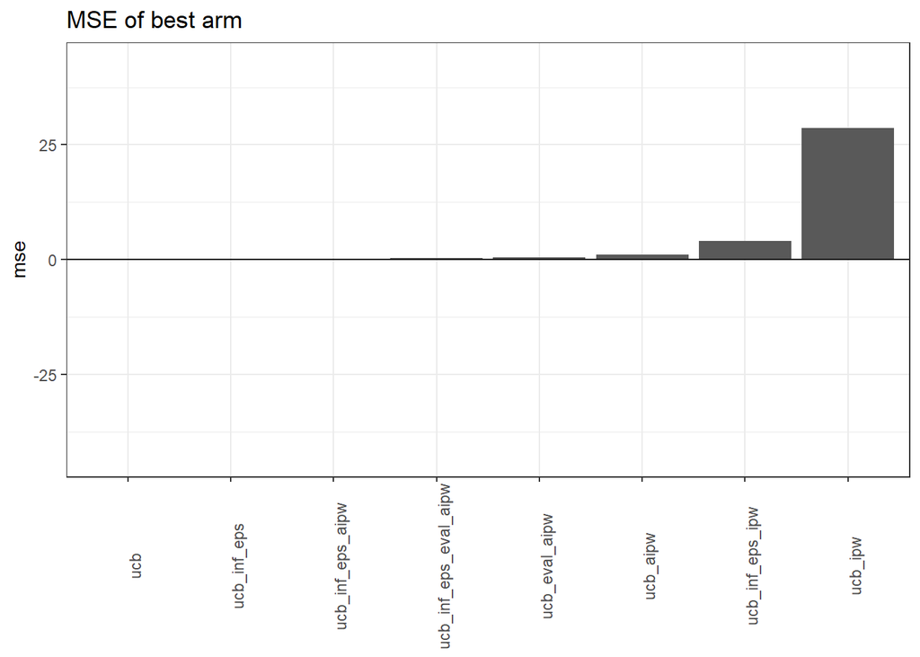

MSE is very very low for all algoritms in terms of scale, the only high values seem to be for weighed estimators.

## MSE of Worst arm

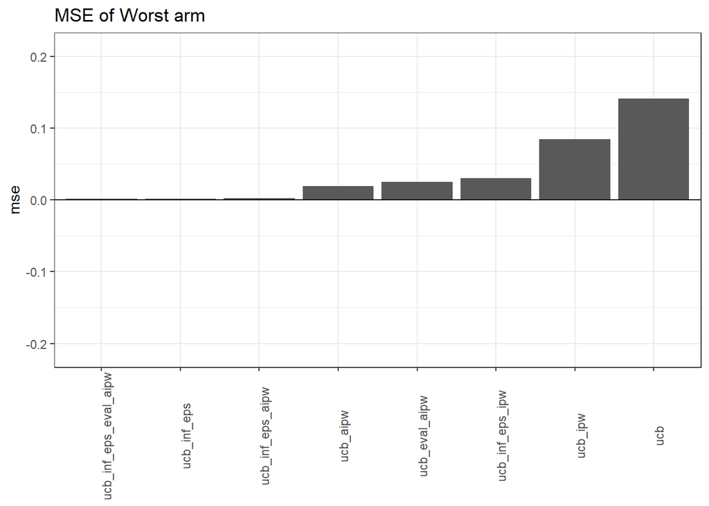

Again, for vanilla MAB algorithms and their weighes estimators, MSE is high. This seem to reduce for INF_EPS algorithms.

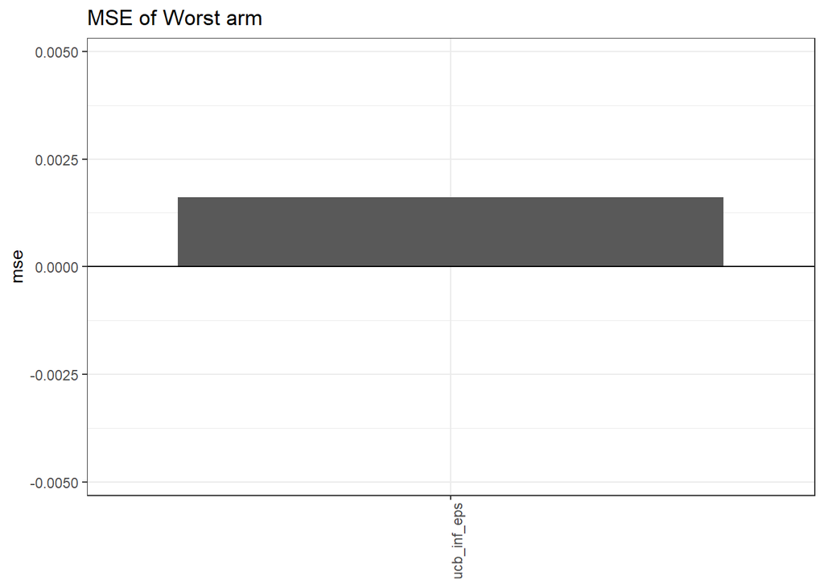

# Conclusions